# R Workshop an der PHSZ

Andrea Cantieni

19.8.19  
13:00 - 17:30  
Raum P01  
Version 2019-08-19 17:08:43

# Inhalt

# Voraussetzungen

- Auf dem eigenen Laptop installiertes und lauffähiges aktuell(st)es R  
  Windows: https://stat.ethz.ch/CRAN/bin/windows/base/  
  Mac: https://stat.ethz.ch/CRAN/bin/macosx/  
  Linux: https://stat.ethz.ch/CRAN/bin/linux/
- Auf dem eigenen Laptop installiertes und lauffähiges aktuell(st)es RStudio  
  https://www.rstudio.com/products/rstudio/download/#download

# Warum R, und nicht SPSS/Mplus oder Python/Julia?

- R ist eine Statistik-*Programmiersprache*
- SPSS ist ein point&click Tool; ja ich weiss, man kann auch Syntax schreiben
- Mplus benutzt eine eigens entwickelte (beschränkte) Makrosprache
- Python ist eine allgemeine Programmiersprache, nicht spezifisch für Statistik
- Julia ist eine Programmiersprache entwickelt für allgemeine wissenschaftliche Zwecke

# Warum RStudio, und nicht R-GUI oder Emacs?

- Das R-GUI ist sehr beschränkt
- Emacs/ESS ist sehr unbeschränkt
- In RStudio gibt es sehr vieles, das man per Mausklick machen kann. Im Allgemeinen sind das keine statistischen Prozeduren o.ä., sonder alles Dinge, die das IDE selbst betreffen, wie z.B. Dateien öffnen oder ein Skript kompilieren. So ziemlich alles ist aber auch per Skript möglich.

# Demo/Hands-on: RStudio UI

[figure not shown]

https://www.rstudio.com/wp-content/uploads/2018/08/rstudio-ide.png

# Demo/Hands-on: R Basics

```r
a <- 1; b <- 2
print(a+b)  # ausdrucken
```

```
## [1] 3
```

```r
d <- c(a, b, a+b)
print(d)
```

```
## [1] 1 2 3
```

```r
set.seed(19819)
df <- data.frame(a=1:5, b=rnorm(5, 0, 1))
print(df)
```

```
##   a         b
## 1 1 1.7089977
## 2 2 0.0734957
## 3 3 0.1029835
## 4 4 0.0361318
## 5 5 0.2497834
```

```r
search()
```

```
##  [1] ".GlobalEnv"        "package:shiny"     "package:ggplot2"
##  [4] "package:lavaan"    "package:lme4"      "package:Matrix"
##  [7] "package:codebook"  "package:readxl"    "package:haven"
## [10] "tools:rstudio"     "package:stats"     "package:graphics"
## [13] "package:grDevices" "package:utils"     "package:datasets"
## [16] "package:methods"   "Autoloads"         "package:base"
```

- Live Demo: colSums, rowSums, lapply, function, plot, hist, boxplot, factor, str, head, names, …

```r
set.seed(19819)
mydata <- data.frame(a=1:100, b=round(rnorm(100, 0, 1),2), g=rep(1:4, each=25))
head(mydata)
```

```
##   a     b g
## 1 1  1.71 1
## 2 2  0.07 1
## 3 3  0.10 1
## 4 4  0.04 1
## 5 5  0.25 1
## 6 6 -0.94 1
```

```r
str(mydata)
```

```
## 'data.frame':    100 obs. of  3 variables:
##  $ a: int  1 2 3 4 5 6 7 8 9 10 ...
##  $ b: num  1.71 0.07 0.1 0.04 0.25 -0.94 0.24 -0.26 -0.93 0.24 ...
##  $ g: int  1 1 1 1 1 1 1 1 1 1 ...
```

```r
names(mydata)
```

```
## [1] "a" "b" "g"
```

# Konzepte R core/base vs. tidyverse

- R [core/base](https://stat.ethz.ch/R-manual/R-patched/doc/html/packages.html) ist das “Fundament”, [tidyverse](https://www.tidyverse.org/packages/) baut darauf auf.

| core/base | tidyverse/dplyr |
| --- | --- |
| `data.frame` | [`tibble`](https://cran.r-project.org/web/packages/tibble/vignettes/tibble.html) |
| `df[rows, cols]` | `select` / `filter` |
| `df$neu` | `mutate` |
| `aggregate` | `group_by` / `summarise` |
| `merge` | `left_join` |

- Demo: Anwendung der Methoden auf `mydata`

```r
class(mydata)
```

```
## [1] "data.frame"
```

```r
library(dplyr)
# select spalten
mydata$b
```

```
##   [1]  1.71  0.07  0.10  0.04  0.25 -0.94  0.24 -0.26 -0.93  0.24 -0.08
##  [12]  0.46  1.31  0.69 -0.03  0.95 -0.24 -0.57  0.98  0.90 -1.47  1.14
##  [23] -1.03 -0.21 -1.01  0.14 -0.73 -0.96  0.78  0.60 -2.00  1.22 -0.15
##  [34] -0.42  0.21  0.16  0.59  2.00 -0.64  0.55  0.57 -0.26 -0.28 -0.51
##  [45] -0.77  1.14 -1.26 -0.69  1.30 -0.15 -1.19  0.83  0.08  0.67 -0.69
##  [56]  0.12  0.95 -0.20 -0.11  1.26 -1.17 -0.65 -1.30 -0.03 -1.39  1.02
##  [67]  0.55 -0.67  0.74  0.58  0.62 -0.01  1.25  1.63  0.48  0.33  1.86
##  [78] -0.96 -1.19  0.52  1.34 -1.20  1.19 -0.11  1.10  1.17 -0.38 -1.52
##  [89]  0.24  0.33 -1.01  1.57 -0.28  0.48  0.72  0.25  0.40  0.36  0.92
## [100]  0.04
```

```r
mydata[,2]
```

```
##   [1]  1.71  0.07  0.10  0.04  0.25 -0.94  0.24 -0.26 -0.93  0.24 -0.08
##  [12]  0.46  1.31  0.69 -0.03  0.95 -0.24 -0.57  0.98  0.90 -1.47  1.14
##  [23] -1.03 -0.21 -1.01  0.14 -0.73 -0.96  0.78  0.60 -2.00  1.22 -0.15
##  [34] -0.42  0.21  0.16  0.59  2.00 -0.64  0.55  0.57 -0.26 -0.28 -0.51
##  [45] -0.77  1.14 -1.26 -0.69  1.30 -0.15 -1.19  0.83  0.08  0.67 -0.69
##  [56]  0.12  0.95 -0.20 -0.11  1.26 -1.17 -0.65 -1.30 -0.03 -1.39  1.02
##  [67]  0.55 -0.67  0.74  0.58  0.62 -0.01  1.25  1.63  0.48  0.33  1.86
##  [78] -0.96 -1.19  0.52  1.34 -1.20  1.19 -0.11  1.10  1.17 -0.38 -1.52
##  [89]  0.24  0.33 -1.01  1.57 -0.28  0.48  0.72  0.25  0.40  0.36  0.92
## [100]  0.04
```

```r
mydata[,2, drop=FALSE]
```

```
##         b
## 1    1.71
## 2    0.07
## 3    0.10
## 4    0.04
## 5    0.25
## 6   -0.94
## 7    0.24
## 8   -0.26
## 9   -0.93
## 10   0.24
## 11  -0.08
## 12   0.46
## 13   1.31
## 14   0.69
```

[output cut: 86 more lines]

```r
mydata %>% select(b)
```

```
##         b
## 1    1.71
## 2    0.07
## 3    0.10
## 4    0.04
## 5    0.25
## 6   -0.94
## 7    0.24
## 8   -0.26
## 9   -0.93
## 10   0.24
## 11  -0.08
## 12   0.46
## 13   1.31
## 14   0.69
```

[output cut: 86 more lines]

```r
# filter zeilen
mydata[mydata$b>1,]
```

```
##     a    b g
## 1   1 1.71 1
## 13 13 1.31 1
## 22 22 1.14 1
## 32 32 1.22 2
## 38 38 2.00 2
## 46 46 1.14 2
## 49 49 1.30 2
## 60 60 1.26 3
## 66 66 1.02 3
## 73 73 1.25 3
## 74 74 1.63 3
## 77 77 1.86 4
## 81 81 1.34 4
## 83 83 1.19 4
## 85 85 1.10 4
## 86 86 1.17 4
## 92 92 1.57 4
```

```r
mydata %>% filter(b>1)
```

```
##     a    b g
## 1   1 1.71 1
## 2  13 1.31 1
## 3  22 1.14 1
## 4  32 1.22 2
## 5  38 2.00 2
## 6  46 1.14 2
## 7  49 1.30 2
## 8  60 1.26 3
## 9  66 1.02 3
## 10 73 1.25 3
## 11 74 1.63 3
## 12 77 1.86 4
## 13 81 1.34 4
## 14 83 1.19 4
## 15 85 1.10 4
## 16 86 1.17 4
## 17 92 1.57 4
```

```r
# mutate spalte
mydata$d <- mydata$b + 1
mydata %>% mutate(d=b+1)
```

```
##       a     b g     d
## 1     1  1.71 1  2.71
## 2     2  0.07 1  1.07
## 3     3  0.10 1  1.10
## 4     4  0.04 1  1.04
## 5     5  0.25 1  1.25
## 6     6 -0.94 1  0.06
## 7     7  0.24 1  1.24
## 8     8 -0.26 1  0.74
## 9     9 -0.93 1  0.07
## 10   10  0.24 1  1.24
## 11   11 -0.08 1  0.92
## 12   12  0.46 1  1.46
## 13   13  1.31 1  2.31
## 14   14  0.69 1  1.69
```

[output cut: 86 more lines]

```r
# aggregate by group
aggregate(mydata$b, by=list(mydata$g), mean)
```

```
##   Group.1      x
## 1       1 0.0924
## 2       2 0.0176
## 3       3 0.1348
## 4       4 0.2468
```

```r
mydata %>% group_by(g) %>% summarise(m=mean(b))
```

```
## # A tibble: 4 x 2
##       g      m
##   <int>  <dbl>
## 1     1 0.0924
## 2     2 0.0176
## 3     3 0.135
## 4     4 0.247
```

```r
# (kreuz)tabelle
table(mydata$g)
```

```
##
##  1  2  3  4
## 25 25 25 25
```

# pisa2012che Datensatz

- Beschreibung des Datensatzes unter [pisa2012che](https://rdrr.io/cran/betas/man/pisa2012che.html)

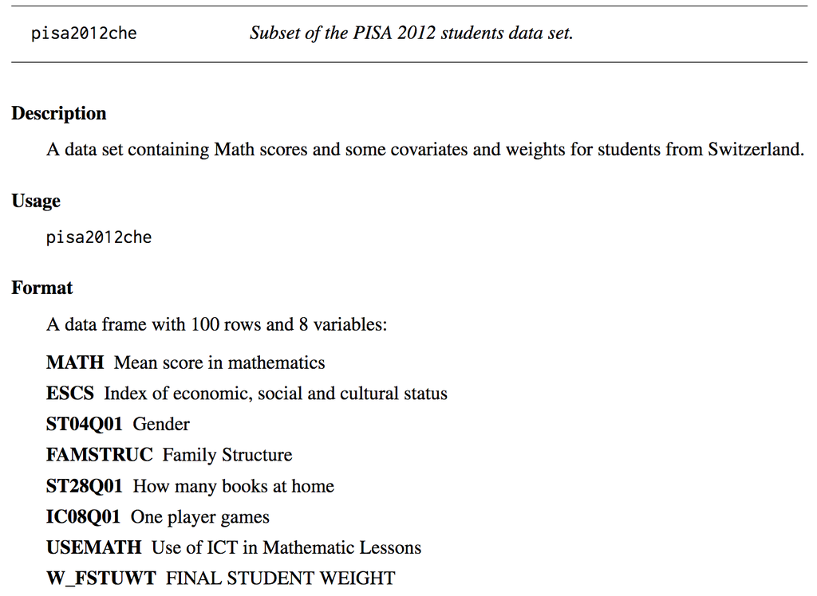

# Demo/Hands-on: Einlesen/Importieren und Dokumentieren von Daten

- Download des `pisa2012che.sav` Datensatzes als SPSS-Datei  
  https://andreaphsz.github.io/rworkshop2019/pisa2012che.sav
- Download des `pisa2012che.xlsx` Datensatzes als Excel-Datei  
  https://andreaphsz.github.io/rworkshop2019/pisa2012che.xlsx
- Einlesen der `pisa2012che.sav` SPSS-Datei mit dem `haven` Package  
  https://cran.r-project.org/package=haven

```r
library(haven)
pisa.sav <- read_sav("pisa2012che.sav")
```

- Einlesen der `pisa2012che.xlsx` Excel-Datei mit dem `readxl` Package  
  https://cran.r-project.org/package=readxl

```r
library(readxl)
pisa.xlsx <- read_xlsx("pisa2012che.xlsx")
```

```
## * `` -> ...1
```

- Codebook erstellen mit dem `codebook` Package  
  https://cran.r-project.org/package=codebook

```r
library(codebook)
new_codebook_rmd()
```

# Demo/Hands-on: ANOVA/ANCOVA und lineare Regression

- ANOVA/ANCOVA ist lineare Regression (http://rpubs.com/candrea/anova-is-regression)
- `anova`, `lm`, `summary`
- Berechnungen mit dem `pisa2012che` Datensatz

```r
fit <- lm(MATH ~ ST04Q01, pisa.sav)
summary(fit)
```

```
##
## Call:
## lm(formula = MATH ~ ST04Q01, data = pisa.sav)
##
## Residuals:
##      Min       1Q   Median       3Q      Max
## -205.547  -66.323   -4.733   64.790  201.292
##
## Coefficients:
##             Estimate Std. Error t value Pr(>|t|)
## (Intercept)   497.64      28.33  17.567   <2e-16 ***
## ST04Q01        10.99      18.72   0.587    0.558
## ---
## Signif. codes:  0 '***' 0.001 '**' 0.01 '*' 0.05 '.' 0.1 ' ' 1
##
## Residual standard error: 92.68 on 98 degrees of freedom
## Multiple R-squared:  0.003506,   Adjusted R-squared:  -0.006663
## F-statistic: 0.3448 on 1 and 98 DF,  p-value: 0.5584
```

```r
summary(pisa.sav)
```

```
##       ESCS            ST04Q01        FAMSTRUC        ST28Q01
##  Min.   :-1.6200   Min.   :1.00   Min.   :1.000   Min.   :1.000
##  1st Qu.:-0.6550   1st Qu.:1.00   1st Qu.:2.000   1st Qu.:2.000
##  Median : 0.1800   Median :1.00   Median :2.000   Median :3.000
##  Mean   : 0.1278   Mean   :1.43   Mean   :1.817   Mean   :3.051
##  3rd Qu.: 0.7300   3rd Qu.:2.00   3rd Qu.:2.000   3rd Qu.:4.000
##  Max.   : 2.7200   Max.   :2.00   Max.   :2.000   Max.   :6.000
##  NA's   :2                        NA's   :7       NA's   :2
##     W_FSTUWT         IC08Q01         USEMATH             MATH
##  Min.   : 1.000   Min.   :1.000   Min.   :-0.7749   Min.   :314.1
##  1st Qu.: 1.694   1st Qu.:1.000   1st Qu.:-0.7749   1st Qu.:446.6
##  Median : 4.261   Median :1.000   Median :-0.7749   Median :506.5
##  Mean   : 6.725   Mean   :1.844   Mean   :-0.0386   Mean   :513.4
##  3rd Qu.: 8.232   3rd Qu.:2.250   3rd Qu.: 0.5798   3rd Qu.:581.6
##  Max.   :31.073   Max.   :5.000   Max.   : 2.8011   Max.   :720.9
##                   NA's   :4       NA's   :3
```

```r
anova(fit)
```

```
## Analysis of Variance Table
##
## Response: MATH
##           Df Sum Sq Mean Sq F value Pr(>F)
## ST04Q01    1   2961  2961.3  0.3448 0.5584
## Residuals 98 841755  8589.3
```

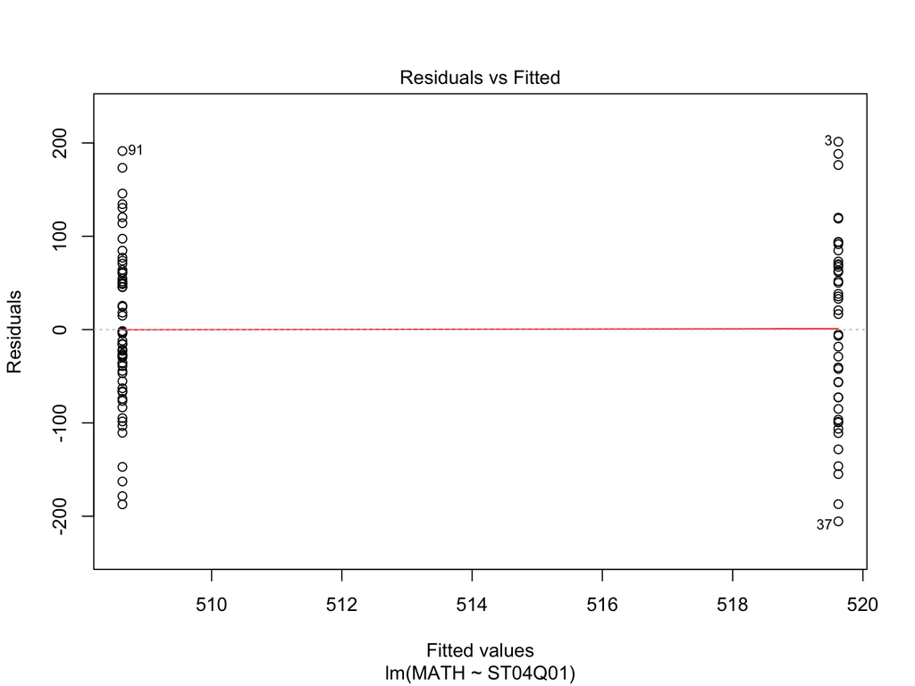

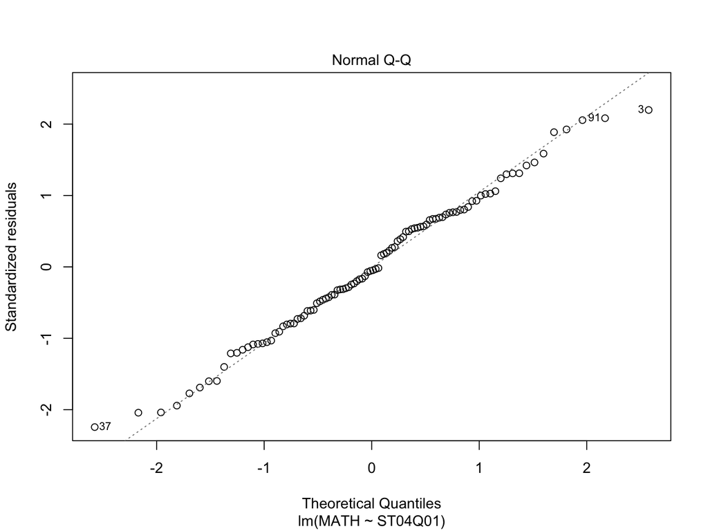

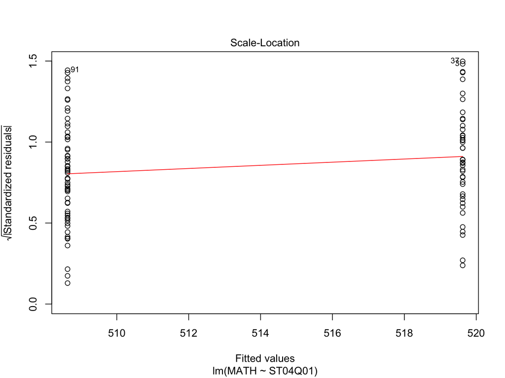

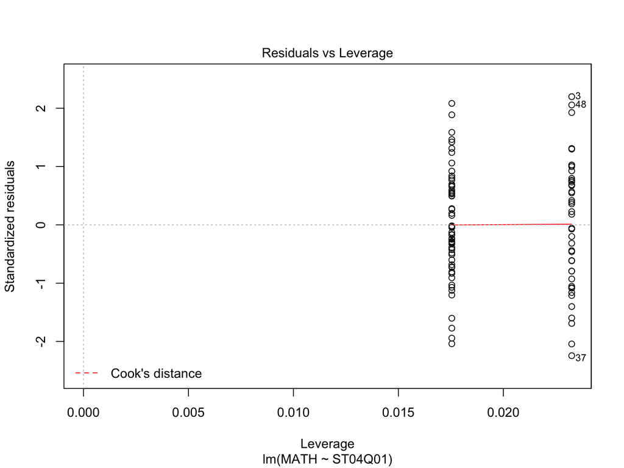

```r
plot(fit)
```

```r
fit2 <- lm(MATH ~ ST04Q01 + ESCS, pisa.sav)
fit3 <- update(fit, . ~ . + ESCS)
```

# Demo/Hands-on: R Markdown/bookdown/pagedown

- Dokumentation: [R Markdown](https://rmarkdown.rstudio.com/lesson-8.html), [bookdown](https://bookdown.org/yihui/bookdown/), [pagedown](https://pagedown.rbind.io/)
- Demo in RStudio: File → New File → R Markdown…

# Demo/Hands-on: lme4

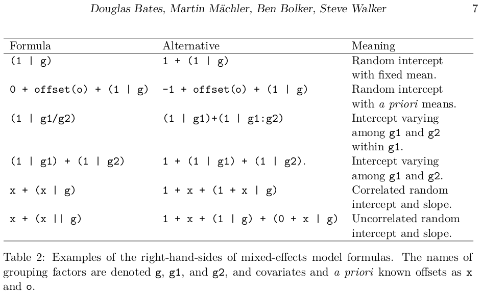

```r
library(lme4)
```

- Z.B. Zwei-Level-Modell mit dem `pisa2012che` Datensatz

# Demo/Hands-on: lavaan

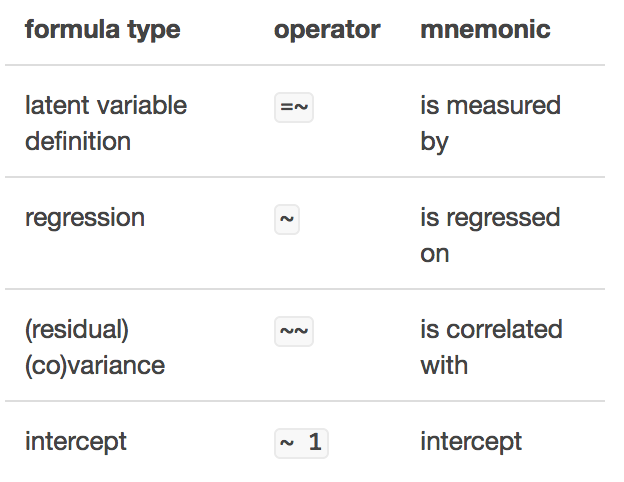

```r
library(lavaan)
```

- Z.B. Pfadmodell mit dem `pisa2012che` Datensatz

# Demo/Hands-on: ggplot2

```r
library(ggplot2)
```

- Erster Schritt: Verwendung des RStudio Addins «‘ggplot2’ builder» [esquisse:::esquisser()]

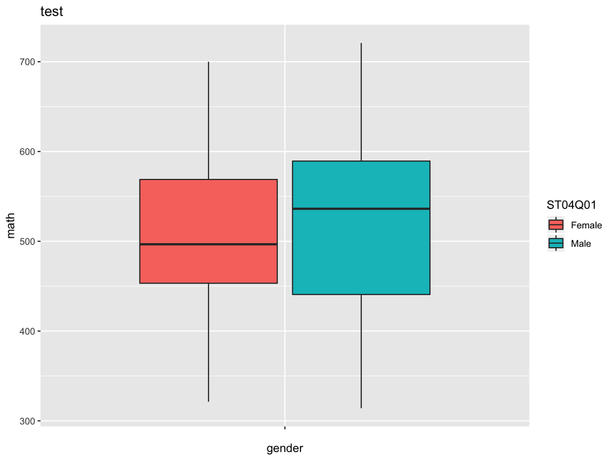

```r
ggplot(pisa.xlsx) +
 aes(x = "", y = MATH, fill = ST04Q01) +
 geom_boxplot() +
 scale_fill_hue() +
 labs(x = "gender", y = "math", title = "test") +
 theme_gray()
```

# Nützliche Links

- [R Project](https://www.r-project.org/)
- [rseek.org](https://rseek.org/)
- [CRAN task views](https://cran.r-project.org/web/views/)
- [R for Data Science](https://r4ds.had.co.nz/)
- [RStudio Webinars](https://resources.rstudio.com/webinars)
- [R Package Documentation](https://rdrr.io/)
- [Zürcher R Kurse](https://www.zhrcourses.uzh.ch/)